# Kaggle-Competition(Olympic Topic)

Ame Liu-22910358@student.uwa.edu.au

### Introduction

My data comes from Kaggle. License is Public Domain.https://www.kaggle.com/mysarahmadbhat/120-years-of-olympic-history The dataset is historical data from the modern Olympic Games, from Athens in 1896 to Rio de Janeiro in 2016. The data includes the athlete’s name, gender, age, height, weight, country, and medal, as well as the project name, sport, game, year, and city, with a unique number for each athlete.

### Data loading, full setup, and overall database data

Load libraries:

```r
library(ggplot2)
library(dplyr)
library(gridExtra)
```

Load the original database:

```r
Olympic1 <-read.csv("/home/ame/PycharmProjects/Kaggle-Data-Analysis/Datasets/athlete_events.csv")
Olympic1
```

| ID | Name | Sex | Age | Height | Weight | Team | NOC | Games | Year | Season | City | Sport | Event | Medal |
| --- | --- | --- | --- | --- | --- | --- | --- | --- | --- | --- | --- | --- | --- | --- |
| 1 | A Dijiang | M | 24 | 180 | 80.0 | China | CHN | 1992 Summer | 1992 | Summer | Barcelona | Basketball | Basketball Men's Basketball | NA |
| 2 | A Lamusi | M | 23 | 170 | 60.0 | China | CHN | 2012 Summer | 2012 | Summer | London | Judo | Judo Men's Extra-Lightweight | NA |
| 3 | Gunnar Nielsen Aaby | M | 24 | NA | NA | Denmark | DEN | 1920 Summer | 1920 | Summer | Antwerpen | Football | Football Men's Football | NA |
| 4 | Edgar Lindenau Aabye | M | 34 | NA | NA | Denmark/Sweden | DEN | 1900 Summer | 1900 | Summer | Paris | Tug-Of-War | Tug-Of-War Men's Tug-Of-War | Gold |
| 5 | Christine Jacoba Aaftink | F | 21 | 185 | 82.0 | Netherlands | NED | 1988 Winter | 1988 | Winter | Calgary | Speed Skating | Speed Skating Women's 500 metres | NA |
| 5 | Christine Jacoba Aaftink | F | 21 | 185 | 82.0 | Netherlands | NED | 1988 Winter | 1988 | Winter | Calgary | Speed Skating | Speed Skating Women's 1,000 metres | NA |
| 5 | Christine Jacoba Aaftink | F | 25 | 185 | 82.0 | Netherlands | NED | 1992 Winter | 1992 | Winter | Albertville | Speed Skating | Speed Skating Women's 500 metres | NA |
| 5 | Christine Jacoba Aaftink | F | 25 | 185 | 82.0 | Netherlands | NED | 1992 Winter | 1992 | Winter | Albertville | Speed Skating | Speed Skating Women's 1,000 metres | NA |
| 5 | Christine Jacoba Aaftink | F | 27 | 185 | 82.0 | Netherlands | NED | 1994 Winter | 1994 | Winter | Lillehammer | Speed Skating | Speed Skating Women's 500 metres | NA |
| 5 | Christine Jacoba Aaftink | F | 27 | 185 | 82.0 | Netherlands | NED | 1994 Winter | 1994 | Winter | Lillehammer | Speed Skating | Speed Skating Women's 1,000 metres | NA |

[output cut: 990 more lines]

Analyze the data with str( ):

```r
str(Olympic1)
```

```
'data.frame':   271116 obs. of  15 variables:
 $ ID    : int  1 2 3 4 5 5 5 5 5 5 ...
 $ Name  : chr  "A Dijiang" "A Lamusi" "Gunnar Nielsen Aaby" "Edgar Lindenau Aabye" ...
 $ Sex   : chr  "M" "M" "M" "M" ...
 $ Age   : int  24 23 24 34 21 21 25 25 27 27 ...
 $ Height: int  180 170 NA NA 185 185 185 185 185 185 ...
 $ Weight: num  80 60 NA NA 82 82 82 82 82 82 ...
 $ Team  : chr  "China" "China" "Denmark" "Denmark/Sweden" ...
 $ NOC   : chr  "CHN" "CHN" "DEN" "DEN" ...
 $ Games : chr  "1992 Summer" "2012 Summer" "1920 Summer" "1900 Summer" ...
 $ Year  : int  1992 2012 1920 1900 1988 1988 1992 1992 1994 1994 ...
 $ Season: chr  "Summer" "Summer" "Summer" "Summer" ...
 $ City  : chr  "Barcelona" "London" "Antwerpen" "Paris" ...
 $ Sport : chr  "Basketball" "Judo" "Football" "Tug-Of-War" ...
 $ Event : chr  "Basketball Men's Basketball" "Judo Men's Extra-Lightweight" "Football Men's Football" "Tug-Of-War Men's Tug-Of-War" ...
 $ Medal : chr  NA NA NA "Gold" ...
```

Analyze the data with summary( ):

```r
summary(Olympic1)
```

```
       ID             Name               Sex                 Age
 Min.   :     1   Length:271116      Length:271116      Min.   :10.00
 1st Qu.: 34643   Class :character   Class :character   1st Qu.:21.00
 Median : 68205   Mode  :character   Mode  :character   Median :24.00
 Mean   : 68249                                         Mean   :25.56
 3rd Qu.:102097                                         3rd Qu.:28.00
 Max.   :135571                                         Max.   :97.00
                                                        NA's   :9474
     Height          Weight          Team               NOC
 Min.   :127.0   Min.   : 25.0   Length:271116      Length:271116
 1st Qu.:168.0   1st Qu.: 60.0   Class :character   Class :character
 Median :175.0   Median : 70.0   Mode  :character   Mode  :character
 Mean   :175.3   Mean   : 70.7
 3rd Qu.:183.0   3rd Qu.: 79.0
 Max.   :226.0   Max.   :214.0
 NA's   :60171   NA's   :62875
    Games                Year         Season              City
 Length:271116      Min.   :1896   Length:271116      Length:271116
 Class :character   1st Qu.:1960   Class :character   Class :character
 Mode  :character   Median :1988   Mode  :character   Mode  :character
                    Mean   :1978
                    3rd Qu.:2002
                    Max.   :2016

    Sport              Event              Medal
 Length:271116      Length:271116      Length:271116
 Class :character   Class :character   Class :character
 Mode  :character   Mode  :character   Mode  :character
```

The amount of data is very large, each player will correspond to different variables, and each Olympic Games will have different variables, choose different indicators will get different data, and the source data is extremely complex.

Analyze the data with head( ):

```r
head(Olympic1)
```

|  | ID | Name | Sex | Age | Height | Weight | Team | NOC | Games | Year | Season | City | Sport | Event | Medal |
| --- | --- | --- | --- | --- | --- | --- | --- | --- | --- | --- | --- | --- | --- | --- | --- |
| 1 | 1 | A Dijiang | M | 24 | 180 | 80 | China | CHN | 1992 Summer | 1992 | Summer | Barcelona | Basketball | Basketball Men's Basketball | NA |
| 2 | 2 | A Lamusi | M | 23 | 170 | 60 | China | CHN | 2012 Summer | 2012 | Summer | London | Judo | Judo Men's Extra-Lightweight | NA |
| 3 | 3 | Gunnar Nielsen Aaby | M | 24 | NA | NA | Denmark | DEN | 1920 Summer | 1920 | Summer | Antwerpen | Football | Football Men's Football | NA |
| 4 | 4 | Edgar Lindenau Aabye | M | 34 | NA | NA | Denmark/Sweden | DEN | 1900 Summer | 1900 | Summer | Paris | Tug-Of-War | Tug-Of-War Men's Tug-Of-War | Gold |
| 5 | 5 | Christine Jacoba Aaftink | F | 21 | 185 | 82 | Netherlands | NED | 1988 Winter | 1988 | Winter | Calgary | Speed Skating | Speed Skating Women's 500 metres | NA |
| 6 | 5 | Christine Jacoba Aaftink | F | 21 | 185 | 82 | Netherlands | NED | 1988 Winter | 1988 | Winter | Calgary | Speed Skating | Speed Skating Women's 1,000 metres | NA |

Count the number of NA for each classification:

```r
apply(is.na(Olympic1), 2, sum)
```

```
    ID   Name    Sex    Age Height Weight   Team    NOC  Games   Year Season
     0      0      0   9474  60171  62875      0      0      0      0      0
  City  Sport  Event  Medal
     0      0      0 231333
```

“Medal” has a lot of NA we understand, because only the most powerful top three have medals, most people do not have medals, and “Age”, “Height”, “Weight” may be due to earlier years of data loss or not written, the use of these variables later to pay attention to remove NA values or other.

#### All data transformations are done separately in each Topic, including data cleansing

### [1]Topic of Olympic Games

#### (1).Count the number of people in each Olympic Games for 120 years

To make a data frame with “Season,” “Year,” “Game,” “Number_of_Participants” to make it easier for us to explore the annual changes in the number of people for each summer and winter Olympics

Data cleaning and creation:

```r
Olympic3<- Olympic1[!duplicated(Olympic1[,c("Season","Year")]),]
Olympic3 <-subset(Olympic3,select=c(Season,Year))
Olympic3 <- Olympic3 [order(Olympic3 [,"Year"],decreasing=F),]
Olympic4  <- Olympic1[!duplicated(Olympic1[,c("ID","Games")]),]
Olympic4  <-subset(Olympic4 ,select=c(Year,Games,Season))
ID_number <- group_by(Olympic4 , Games)
History_Number<- summarise(ID_number,Number_of_Participants = n())
rownames(Olympic3) <-NULL
rownames(Olympic3) <- rownames(Olympic3, do.NULL = FALSE)
Olympic3 <- Olympic3 [order(Olympic3 [,"Year"],decreasing=F),]
Olympic3 <- arrange(Olympic3,Olympic3[,"Year"],Olympic3[,"Season"])
History_Number<- cbind(Olympic3,History_Number)
rownames(History_Number) <-NULL
rownames(History_Number) <- rownames(History_Number, do.NULL = FALSE)
#The new data frame is as follows: #
History_Number    #new data frame #
```

|  | Season | Year | Games | Number_of_Participants |
| --- | --- | --- | --- | --- |
| 1 | Summer | 1896 | 1896 Summer | 176 |
| 2 | Summer | 1900 | 1900 Summer | 1224 |
| 3 | Summer | 1904 | 1904 Summer | 650 |
| 4 | Summer | 1906 | 1906 Summer | 841 |
| 5 | Summer | 1908 | 1908 Summer | 2024 |
| 6 | Summer | 1912 | 1912 Summer | 2409 |
| 7 | Summer | 1920 | 1920 Summer | 2676 |
| 8 | Summer | 1924 | 1924 Summer | 3256 |
| 9 | Winter | 1924 | 1924 Winter | 313 |
| 10 | Summer | 1928 | 1928 Summer | 3247 |

[output cut: 41 more lines]

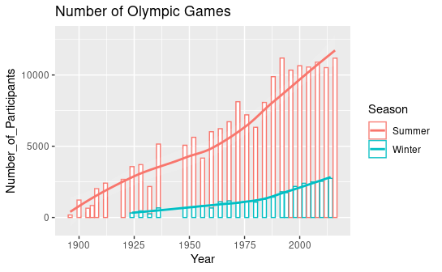

```r
ggplot(History_Number,aes(x = Year, y= Number_of_Participants,color=Season))+geom_bar(stat="identity",fill="white")+geom_smooth(method = 'loess',formula='y ~ x',fill="white",alpha=.100)+ggtitle("Number of Olympic Games")
```

The new data frame details the number of people corresponding to each Olympic Games obtained after the source data is cleaned. First of all, the overall number of people in all Winter Olympics and Summer Olympics is on the rise. Secondly, the number of participants in the Summer Olympics is far greater than that of the Winter Olympics. Finally, the data in the middle paragraphs are empty due to the influence of the world war at that time.

#### (2).The number of sports in the Olympic Games

We need to get all the Sports categories and all theevents specific to each sport. Data cleaning and creation:

```r
#Data cleaning#
Topic_Sport<-subset(Olympic1,select=c(Sport,Event))       #Extract related categories#
Topic_Sport<- Topic_Sport[!duplicated(Topic_Sport[,c("Event")]),]    #Removes heavy duplicate data#
rownames(Topic_Sport) <- NULL
All_Sport <- Topic_Sport [order(Topic_Sport [,"Sport"],decreasing=F),]
rownames(All_Sport) <- NULL
rownames(All_Sport) <- rownames(All_Sport, do.NULL = FALSE)
#Olympic Games all Events#
All_Sport
```

|  | Sport | Event |
| --- | --- | --- |
| 1 | Aeronautics | Aeronautics Mixed Aeronautics |
| 2 | Alpine Skiing | Alpine Skiing Men's Downhill |
| 3 | Alpine Skiing | Alpine Skiing Men's Super G |
| 4 | Alpine Skiing | Alpine Skiing Men's Giant Slalom |
| 5 | Alpine Skiing | Alpine Skiing Men's Slalom |
| 6 | Alpine Skiing | Alpine Skiing Men's Combined |
| 7 | Alpine Skiing | Alpine Skiing Women's Slalom |
| 8 | Alpine Skiing | Alpine Skiing Women's Giant Slalom |
| 9 | Alpine Skiing | Alpine Skiing Women's Super G |
| 10 | Alpine Skiing | Alpine Skiing Women's Combined |

[output cut: 755 more lines]

```r
ID_number <- group_by(Topic_Sport , Sport)
Topic_Sport2  <- summarise(ID_number,Count = n())
Topic_Sport2 <- data.frame(Topic_Sport2)
#The number of Events per Sport#
Topic_Sport2
```

| Sport | Count |
| --- | --- |
| Aeronautics | 1 |
| Alpine Skiing | 10 |
| Alpinism | 1 |
| Archery | 29 |
| Art Competitions | 29 |
| Athletics | 83 |
| Badminton | 5 |
| Baseball | 1 |
| Basketball | 2 |
| Basque Pelota | 1 |

[output cut: 56 more lines]

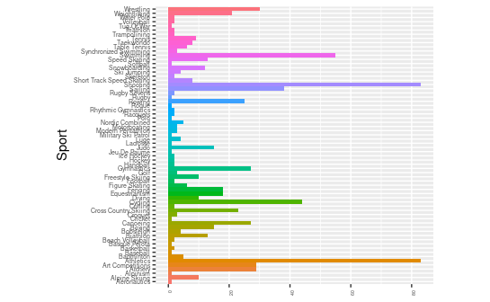

```r
#Drawing#
bar <- ggplot(data = Topic_Sport) +
geom_bar(mapping = aes(x = Sport, y=..count..,fill = Sport),show.legend = FALSE,width = 1) +theme(aspect.ratio = 1) +labs(y = NULL)
p1 <- bar + coord_flip()+ theme(axis.text.x = element_text(angle = 90, hjust = 1, size = 4),axis.text.y = element_text(angle =  0, size = 5.2))
p2 <- bar + coord_polar()+ theme(axis.text.x = element_text(angle = 0, hjust = 1, size = 2.8),axis.text.y = element_text(angle =  0, size = 0))

p1+theme(aspect.ratio = 1)  #All Events#
```

```r
#Select the top 10#
Topic_Sport3 <- Topic_Sport2 [order(Topic_Sport2 [,"Count"],decreasing=T),]
Top10_Sport <- Topic_Sport3 [1:10,]
rownames(Top10_Sport) <-NULL
rownames(Top10_Sport) <- rownames(Top10_Sport, do.NULL = FALSE)
Top10_Sport
```

|  | Sport | Count |
| --- | --- | --- |
| 1 | Athletics | 83 |
| 2 | Shooting | 83 |
| 3 | Swimming | 55 |
| 4 | Cycling | 44 |
| 5 | Sailing | 38 |
| 6 | Wrestling | 30 |
| 7 | Archery | 29 |
| 8 | Art Competitions | 29 |
| 9 | Canoeing | 27 |
| 10 | Gymnastics | 27 |

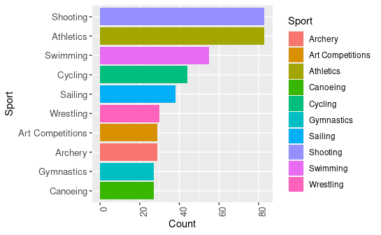

```r
#Drawing#
Top10_Sport <- Top10_Sport [order(Top10_Sport[,"Count"],decreasing=F),]
bar2 <- ggplot(Top10_Sport,aes(x = Sport, y= Count,fill=Sport))+geom_bar(stat="identity")+scale_x_discrete(limits=factor(Top10_Sport[,1]))
p3 <- bar2 +coord_flip()+theme(axis.text.x = element_text(angle = 90, hjust = 1, size = 10),
        axis.text.y = element_text(angle =  0, size = 10))
p4 <- bar2 + coord_polar()+theme(axis.text.x = element_text(angle = 0, hjust = 1, size = 0),
        axis.text.y = element_text(angle =  0, size = 10))
p3  #Top10_Sport #
```

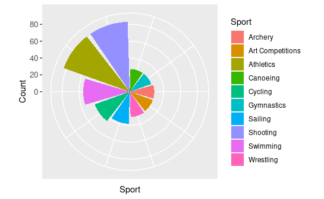

```r
p4  #Top10_Sport #
```

After data cleaning of the source data, we have obtained a large amount of clear new data. The first data frame shows all the Olympic sports; the second data frame shows in detail how many events are included in all Olympic sports; the third data frame shows the top 10 Olympic sports. First of all, the first picture vividly shows the number of events corresponding to each Olympic sport. We can see that items such as “Shooting” and “Athletics” are among the best.Secondly, in the second picture, we get the number of items corresponding to the top 10 sports by filtering and sorting the top 10 sports. Finally, the last picture shows their approximate proportions and numbers. #### (3).Summer Olympic and Winter Olympic Explore the total number of people who have participated in the Summer and Winter Olympics since the 120s Data cleaning and creation:

```r
#Data cleaning#
Topic_Season<-subset(Olympic1,select=c(ID,Season))       #Select useful columns#
Topic_Season<- Topic_Season[!duplicated(Topic_Season[,c("ID","Season")]),]   #Removes heavy duplicate data#
rownames(Topic_Season) <- NULL
rownames(Topic_Season) <- rownames(Topic_Season, do.NULL = FALSE)      #format#
ID_number <- group_by(Topic_Season, Season)
Summer_Winter <- summarise(ID_number,Count = n())
Summer_Winter    #Summer and Winter#
```

| Season | Count |
| --- | --- |
| Summer | 116776 |
| Winter | 18958 |

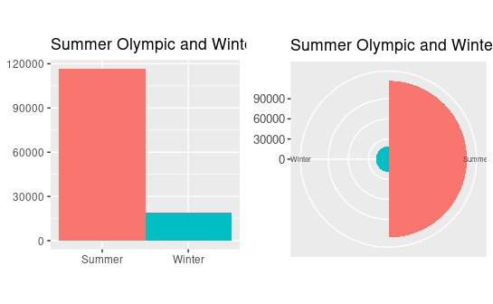

```r
#Drawing#
bar <- ggplot(data = Topic_Season) +geom_bar(mapping = aes(x = Season, fill = Season),show.legend = FALSE,width = 1)+theme(aspect.ratio = 1)+labs(x = NULL, y = NULL)+ggtitle("Summer Olympic and Winter Olympic")
p1 <- bar
p2 <- bar + coord_polar()+theme(axis.text.x = element_text(angle = 0, hjust = 1, size = 6),
        axis.text.y = element_text(angle =  0, size = 10),
        axis.title.x = element_blank(),
        axis.title.y = element_blank())
grid.arrange(p1, p2, ncol=2)  #Summer and Winter#
```

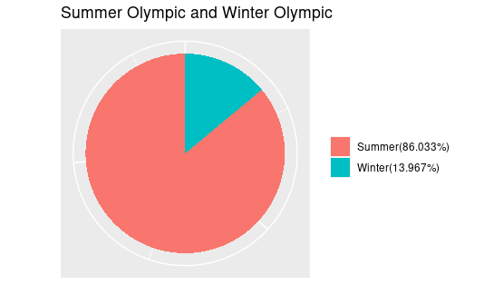

```r
ID_number <- group_by(Topic_Season, Season)
qwe <- summarise(ID_number,Count= n())
Label = as.vector(qwe$Season)          #Turn into a vector#
Label1 = paste(Label, "(", round(qwe$Count/sum(qwe$Count)*100, 3), "%)", sep = "")     #Keep three decimal places on the result#
p <- ggplot(qwe, aes(x = '', y = Count, fill = Season))+
geom_bar(stat = 'identity', width = 1) +          #The noise in the center disappears when the width > 1#
coord_polar(theta = 'y')+
labs(x = "", y = "", title = "") +
theme(axis.ticks = element_blank()) +   # Remove the scale of the top left border#
scale_fill_discrete(breaks = qwe$Season, labels = Label1)+
theme(legend.title = element_blank())+
theme(axis.text.x = element_blank())+ggtitle("Summer Olympic and Winter Olympic")
p     #Proportion#
```

By cleaning the data, we have obtained a new table that clearly shows the number of participants in the Summer Olympics and Winter Olympics over the past 120 years. First of all, the first picture shows that the number of participants in the Olympics is far more than the Winter Olympics through the comparison of histograms. The last picture shows the proportion of participants in the Summer and Winter Olympics, which accounted for 86% of the total number of participants in the 120 years. ### [2]Topic of Olympic athletes

#### (1).Gender differences

Explore the differences in height and weight between Olympic athletes of different genders and the number of men and women participating Data cleaning and creation:

```r
#Data Cleaning#
#Select useful information in the source data#
Topic_Sex <-subset(Olympic1,select=c(ID,Height,Weight,Sex))
Topic_Sex<- Topic_Sex[!duplicated(Topic_Sex[,c("ID")]),]     #Remove repeat contestants#
rownames(Topic_Sex) <- NULL           #Initialize the data#
rownames(Topic_Sex) <- rownames(Topic_Sex, do.NULL = FALSE)
Topic_Sex    #Each player's height, weight, gender#
```

|  | ID | Height | Weight | Sex |
| --- | --- | --- | --- | --- |
| 1 | 1 | 180 | 80.0 | M |
| 2 | 2 | 170 | 60.0 | M |
| 3 | 3 | NA | NA | M |
| 4 | 4 | NA | NA | M |
| 5 | 5 | 185 | 82.0 | F |
| 6 | 6 | 188 | 75.0 | M |
| 7 | 7 | 183 | 72.0 | M |
| 8 | 8 | 168 | NA | F |
| 9 | 9 | 186 | 96.0 | M |
| 10 | 10 | NA | NA | M |

[output cut: 990 more lines]

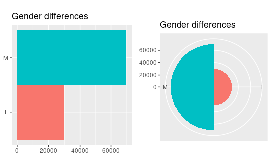

```r
#Drawing#
Topic_Sex<- na.omit(Topic_Sex)
bar <- ggplot(data = Topic_Sex) + geom_bar(mapping = aes(x = Sex, fill = Sex),
show.legend = FALSE,width = 1) + theme(aspect.ratio = 1) + labs(x = NULL, y = NULL)+ggtitle("Gender differences")
p1 <- bar + coord_flip()     #Swap coordinate systems#
p2 <- bar + coord_polar()
grid.arrange(p1, p2, ncol=2)     #Total number#
```

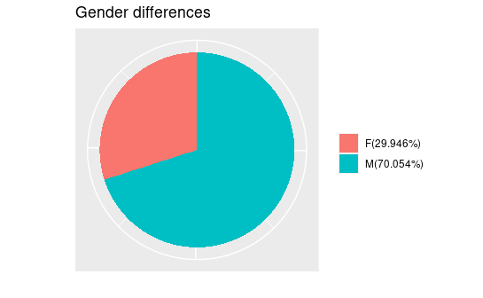

```r
ID_number <- group_by(Topic_Sex,Sex)
Data <- summarise(ID_number,Count= n())
Label = as.vector(Data$Sex) #Turn into a vector#
Label1 = paste(Label, "(", round(Data$Count/sum(Data$Count)*100, 3), "%)", sep = "")  #Keep three decimal places on the result#
p3 <- ggplot(Data, aes(x = '', y = Count, fill = Sex))+
geom_bar(stat = 'identity', width = 1) +  #The noise in the center disappears when the width > 1#
coord_polar(theta = 'y')+
labs(x = "", y = "", title = "") +
theme(axis.ticks = element_blank()) +     # Remove the scale of the top left border#
scale_fill_discrete(breaks = Data$Sex, labels = Label1)+
theme(legend.title = element_blank())+
theme(axis.text.x = element_blank())+ggtitle("Gender differences")
p3        #The ratio of men to women#
```

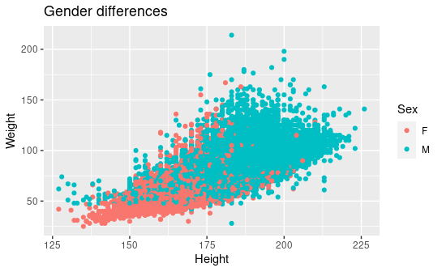

```r
ggplot(Topic_Sex,aes(x=Height,y=Weight,color=Sex),)+geom_point()+ggtitle("Gender differences")    #Distribution chart#
```

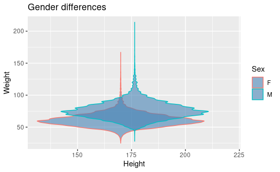

```r
ggplot(Topic_Sex,aes(x=Height,y=Weight,color=Sex,fill="white"))+geom_violin(fill="steelblue",alpha=.6)+ggtitle("Gender differences")
```

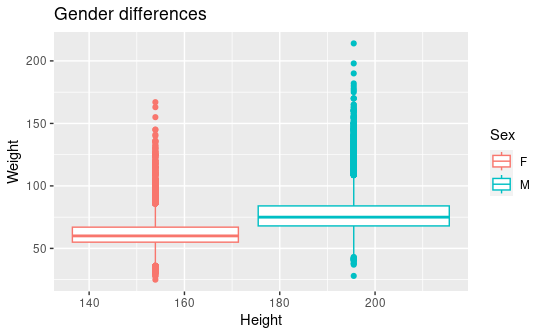

```r
ggplot(Topic_Sex,aes(x=Height,y=Weight,color=Sex,fill="white"))+geom_boxplot(fill="white")+ggtitle("Gender differences")#Distribution chart#
```

```r
NA
NA
```

We obtained a new data frame by reducing and repeating the source data, which showed in detail all the weight, height and gender information corresponding to each player ID. First of all, the first and second pictures show the number and ratio of male and female athletes participating in the Olympic Games for 120 years. We can see that there are far more male athletes than women. Secondly, through the third scatter chart, we found that the overall height and weight of male athletes and female athletes are quite different, which is caused by the human body structure. Finally, through the final violin chart and box chart, we removed many atypical data. We can find that the overall weight of female athletes is around 60kg, while the overall weight of male athletes is around 75kg; the overall height of female athletes is around 170cm, and the overall height of male athletes is around 180cm. about. #### (2)Multi-sport athletes Are there any athletes who participate in many sports alone? Data cleaning and creation:

```r
#Data Cleaning#
Topic_SportNumber<-subset(Olympic1,select=c(ID,Sport))
Topic_SportNumber<- Topic_SportNumber[!duplicated(Topic_SportNumber[,c("ID","Sport")]),]
row.names(Topic_SportNumber) <- NULL
rownames(Topic_SportNumber ) <- rownames(Topic_SportNumber , do.NULL = FALSE)
ID_number <- group_by(Topic_SportNumber, ID)
Types1 <- summarise(ID_number,Types = n())
ID_number <- group_by(Types1 , Types)
Types1  <- summarise(ID_number,Count = n())
Types1 <- data.frame(Types1)
#Accurate data for Multi-sport athletes #
Types1
```

| Types | Count |
| --- | --- |
| 1 | 134563 |
| 2 | 930 |
| 3 | 72 |
| 4 | 6 |

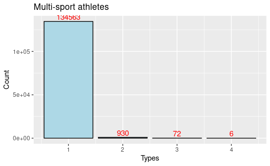

```r
#Drawing#
ggplot(Types1,aes(Types,Count))+geom_bar(stat="identity",fill = "lightblue", colour = "black")+ggtitle("Multi-sport athletes")+geom_text(aes(label = Count), vjust = -0.3, colour = "red", position = position_dodge(.7), size = 4)
```

By cleaning the data, we have obtained clear data. As shown in the first data box, there are indeed athletes participating in different types of Olympic sports. Through the display of the histogram, we found that very few remote mobilizations participated in different types of sports in the Olympic Games, and only 6 people participated in 4 events, which is very rare. It can be seen that athletes who are proficient in many different types of Olympic Games are very rare, and most people only participate in a single category of Olympic sports in their lifetime.

#### (3)Retirement_Age-Participations

Explore the number of times each athlete has participated in the Olympics and the age of retirement over the past 120 years Data cleaning and creation:

```r
#Data Cleaning#
#Filter the useless variables in this exploration#
Olympic2 <- Olympic1[!duplicated(Olympic1[,c("ID","Games")]),]
Olympic2 <- Olympic2[, !colnames(Olympic2) %in% c("Sport","Event","Medal")]
rownames(Olympic2) <-NULL
rownames(Olympic2) <- rownames(Olympic2, do.NULL = FALSE)  #The initial line name#
ID_Age<-subset(Olympic2,select=c(ID,Age,Sex))
ID_number <- group_by(ID_Age, ID)
ID_Age <- summarise(ID_number,Number_of_Participants = n(),Retirement_Age = max(Age))
ID_Age <- data.frame(ID_Age)
row.names(ID_Age) <- NULL
rownames(ID_Age ) <- rownames(ID_Age , do.NULL = FALSE)
Sex <- (subset(Olympic2[!duplicated(Olympic2[,c("ID")]),],select=c(Sex)))
rownames(Sex) <- NULL
rownames(Sex) <- rownames(Sex, do.NULL = FALSE)
ID_Age_Sex <- cbind(ID_Age,Sex)
ID_Age_Sex <- na.omit(ID_Age_Sex)
ID_Age_Sex     #Parameters: Player ID, number of participants, gender#
```

|  | ID | Number_of_Participants | Retirement_Age | Sex |
| --- | --- | --- | --- | --- |
| 1 | 1 | 1 | 24 | M |
| 2 | 2 | 1 | 23 | M |
| 3 | 3 | 1 | 24 | M |
| 4 | 4 | 1 | 34 | M |
| 5 | 5 | 3 | 27 | F |
| 6 | 6 | 2 | 33 | M |
| 7 | 7 | 2 | 33 | M |
| 8 | 8 | 1 | 18 | F |
| 9 | 9 | 1 | 26 | M |
| 10 | 10 | 1 | 26 | M |

[output cut: 990 more lines]

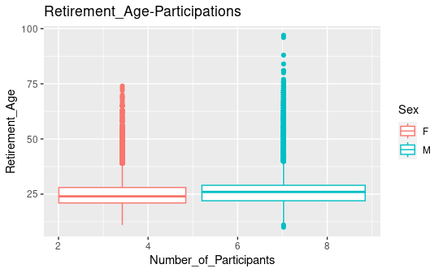

```r
#Drawing#
#The relationship between cumulative participation and retirement age#
ggplot(ID_Age_Sex,aes(x=Number_of_Participants,y=Retirement_Age,color=Sex))+geom_boxplot()+ggtitle("Retirement_Age-Participations")
```

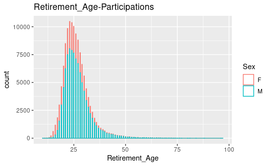

```r
#Retirement age statistics#
ggplot(ID_Age_Sex, aes(x =Retirement_Age,color=Sex)) +geom_histogram(bins = 500,fill="white")+ggtitle("Retirement_Age-Participations")
```

```r
#Data Cleaning#
Topic_Country1 <- subset(Olympic1,select=c(NOC,Medal))
Topic_Country1  <-na.omit(Topic_Country1 )
rownames(Topic_Country1) <- NULL
rownames(Topic_Country1) <- rownames(Topic_Country1, do.NULL = FALSE)
ID_number <- group_by(Topic_Country1, NOC)
Topic_Country <- summarise(ID_number,All_Medals= n())
Topic_Country <- data.frame(Topic_Country)
rownames(Topic_Country) <- NULL
rownames(Topic_Country) <- rownames(Topic_Country, do.NULL = FALSE)
#ranked medals for 120 years#
Topic_Country
```

|  | NOC | All_Medals |
| --- | --- | --- |
| 1 | AFG | 2 |
| 2 | AHO | 1 |
| 3 | ALG | 17 |
| 4 | ANZ | 29 |
| 5 | ARG | 274 |
| 6 | ARM | 16 |
| 7 | AUS | 1320 |
| 8 | AUT | 450 |
| 9 | AZE | 44 |
| 10 | BAH | 40 |

[output cut: 139 more lines]

```r
Topic_Country <- Topic_Country [order(Topic_Country [,"All_Medals"],decreasing=T),]
Top10_Country <- Topic_Country [1:10,]
rownames(Top10_Country ) <- NULL              #Initialize the data and rearrange the row names in order
rownames(Top10_Country ) <- rownames(Top10_Country , do.NULL = FALSE)
#Select the top 10#
Top10_Country
```

|  | NOC | All_Medals |
| --- | --- | --- |
| 1 | USA | 5637 |
| 2 | URS | 2503 |
| 3 | GER | 2165 |
| 4 | GBR | 2068 |
| 5 | FRA | 1777 |
| 6 | ITA | 1637 |
| 7 | SWE | 1536 |
| 8 | CAN | 1352 |
| 9 | AUS | 1320 |
| 10 | RUS | 1165 |

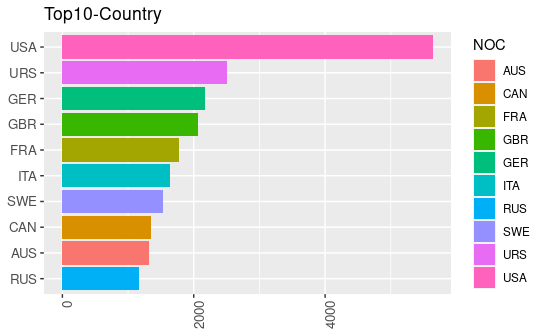

```r
#Drawing#
Top10_Country  <- Top10_Country  [order(Top10_Country[,"All_Medals"],decreasing=F),]
bar <- ggplot(Top10_Country ,aes(x = NOC, y= All_Medals,fill=NOC))+geom_bar(stat="identity")+scale_x_discrete(limits=factor(Top10_Country [,1]))
p1 <- bar +coord_flip()+theme(axis.text.x = element_text(angle = 90, hjust = 1, size = 10),
        axis.text.y = element_text(angle =  0, size = 10),
        axis.title.x = element_blank(),
        axis.title.y = element_blank())+ggtitle("Top10-Country")
p2 <- bar + coord_polar()+theme(axis.text.x = element_text(angle = 0, hjust = 1, size = 0),
        axis.text.y = element_text(angle =  0, size = 10),
        axis.title.x = element_blank(),
        axis.title.y = element_blank())+ggtitle("Top10-Country")
p1    #Top10-County#
```

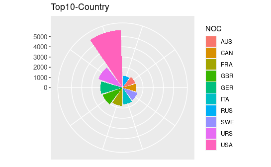

```r
p2    #Top10-County#
```

```r
#Data Creating and Data Cleaning#
Developed_Country <- filter(Topic_Country1, NOC == "USA" | NOC == "CAN" | NOC == "AUS"|NOC == "NZL" | NOC == "GBR"|NOC == "IRL" | NOC == "FRA"|NOC == "NED" | NOC == "BEL"|NOC == "LUX" | NOC == "GER"|NOC == "AUT" | NOC == "SUI"|NOC == "NOR" | NOC == "ISL"|NOC == "DEN"| NOC == "SWE"|NOC == "FIN" | NOC == "ITA"|NOC == "ESP" | NOC == "POR"|NOC == "GRE"| NOC == "SLO"|NOC == "CZE"| NOC == "TCH"|NOC == "MLT" |NOC == "CYP"| NOC == "JPN"|NOC == "KOR"| NOC == "SGP"|NOC == "SR" )
Developing_Country <- filter(Topic_Country1, NOC != "USA" & NOC != "CAN" & NOC != "AUS"& NOC != "NZL" & NOC != "GBR"& NOC != "IRL" & NOC != "FRA"& NOC != "NED" & NOC != "BEL"& NOC != "LUX" & NOC != "GER"& NOC != "AUT" & NOC != "SUI" & NOC != "NOR" & NOC != "ISL"& NOC != "DEN"& NOC != "SWE"& NOC != "FIN" & NOC != "ITA"& NOC != "ESP" & NOC != "POR" & NOC != "GRE"& NOC != "SLO"& NOC != "CZE"& NOC != "TCH"& NOC != "MLT" & NOC != "CYP"& NOC != "JPN"&NOC != "KOR"& NOC != "SGP" &NOC!= "SR")
Developing_Country$Country_type <- c("Developing")
Developed_Country$Country_type <-  c("Developed")
All <- rbind(Developed_Country,Developing_Country)
Developed <- filter(Topic_Country, NOC == "USA" | NOC == "CAN" | NOC == "AUS"|NOC == "NZL" | NOC == "GBR"|NOC == "IRL" | NOC == "FRA"|NOC == "NED" | NOC == "BEL"|NOC == "LUX" | NOC == "GER"|NOC == "AUT" | NOC == "SUI"|NOC == "NOR" | NOC == "ISL"|NOC == "DEN"| NOC == "SWE"|NOC == "FIN" | NOC == "ITA"|NOC == "ESP" | NOC == "POR"|NOC == "GRE"| NOC == "SLO"|NOC == "CZE"| NOC == "TCH"|NOC == "MLT" |NOC == "CYP"| NOC == "JPN"|NOC == "KOR"| NOC == "SGP"|NOC == "SR" )
Developing <- filter(Topic_Country, NOC != "USA" & NOC != "CAN" & NOC != "AUS"& NOC != "NZL" & NOC != "GBR"& NOC != "IRL" & NOC != "FRA"& NOC != "NED" & NOC != "BEL"& NOC != "LUX" & NOC != "GER"& NOC != "AUT" & NOC != "SUI" & NOC != "NOR" & NOC != "ISL"& NOC != "DEN"& NOC != "SWE"& NOC != "FIN" & NOC != "ITA"& NOC != "ESP" & NOC != "POR" & NOC != "GRE"& NOC != "SLO"& NOC != "CZE"& NOC != "TCH"& NOC != "MLT" & NOC != "CYP"& NOC != "JPN"&NOC != "KOR"& NOC != "SGP" &NOC!= "SR")
Developing$Country_type <- c("Developing")    #Developing countries that have won medals for 120 years#
rownames(Developed) <- NULL                   #Initialize the data and re-arrange the row names in order#
rownames(Developed) <- rownames(Developed, do.NULL = FALSE)
Developed$Country_type <- c("Developed")      #Developed countries that have won medals in 120 years#
All_Country <- rbind(Developed,Developing)
  #All countries that have won medals in 120 years#
All_Country<- All_Country[order(All_Country[,"All_Medals"],decreasing=T),]
rownames(All_Country) <- NULL        #Initialize the data and re-arrange the row names in order#
rownames(All_Country ) <- rownames(All_Country , do.NULL = FALSE)
All_Country
```

|  | NOC | All_Medals | Country_type |
| --- | --- | --- | --- |
| 1 | USA | 5637 | Developed |
| 2 | URS | 2503 | Developing |
| 3 | GER | 2165 | Developed |
| 4 | GBR | 2068 | Developed |
| 5 | FRA | 1777 | Developed |
| 6 | ITA | 1637 | Developed |
| 7 | SWE | 1536 | Developed |
| 8 | CAN | 1352 | Developed |
| 9 | AUS | 1320 | Developed |
| 10 | RUS | 1165 | Developing |

[output cut: 139 more lines]

[figure not shown]

```r
#Drawing#
bar <- ggplot(data = All) +geom_bar(mapping = aes(x = Country_type, fill = Country_type,),show.legend = FALSE,width = 1)+theme(aspect.ratio = 1)
p1 <- bar

Label = as.vector(All_Country $Country_type)         #Turn into a vector#
Label1 = paste(Label, "(", round(All_Country $All_Medals/sum(All_Country$All_Medals)*490, ), "%)", sep = "")      #Keep three decimal places on the result#
p2 <- ggplot(All_Country , aes(x = '', y = All_Medals, fill = Country_type))+     #Create an axes#
geom_bar(stat = 'identity', width = 1) +     #The noise in the center disappears when the width > 1#
coord_polar(theta = 'y')+                #Fold the bar chart into a pie chart (polar coordinates)#
labs(x = "", y = "", title = "") +       #Set the label for the horizontal coordinates to empty#
theme(axis.ticks = element_blank()) +   # Remove the scale of the top left border#
scale_fill_discrete(breaks = All_Country $Country_type, labels = Label1)+
theme(legend.title = element_blank())+
theme(axis.text.x = element_blank())

grid.arrange(p1, p2, ncol=2)    #Proportion#
```

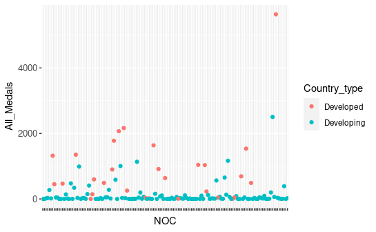

```r
ggplot(All_Country,aes(x=NOC,y=All_Medals,color=Country_type))+geom_point()+theme(axis.text.x = element_text(angle = 0, hjust = 1, size = 0),
        axis.text.y = element_text(angle =  0, size = 10),)    #Distribution chart#
```

### Conclusion

This project includes 3 major themes and 8 specific categories, using 7 different types of statistical charts, including bar chart, curve chart, sector chart, polar chart, scatter chart, violin chart and box chart, a large number of data cleaning, creation, and ideas of exploring big data. The above materials show the great information brought to us by the 120-year history of the Olympic Games.